# Rossmann Feature Exploration

```r
require(ggplot2)
require(hexbin)
require(dplyr)
require(memisc)
require(rpart)
require(rpart.plot)
require(randomForest)
require(xgboost)
```

```r
# Read in preprocessed data.
set.seed(1337)
clean = read.csv("data/clean.csv")
clean$Store = factor(clean$Store)
clean$DayOfWeek = factor(clean$DayOfWeek)
clean$Promo = factor(clean$Promo)
clean$SchoolHoliday = factor(clean$SchoolHoliday)
clean$Promo2 = factor(clean$Promo2)
clean$Date.DayOfMonth = factor(clean$Date.DayOfMonth)
clean$Date.Month = factor(clean$Date.Month)
clean$CompetitionOpened = factor(clean$CompetitionOpened)
clean$Promo2Begun = factor(clean$Promo2Begun)
```

# Feature-Feature Exploration

It should be noted here, that many NA values for Competition Tenure / Distance and Promo2 Tenure have been set equal to the median, and should be considered when comparing features.

Although we can’t know customer count in the future, we can look at the correlation of customer count and sales.

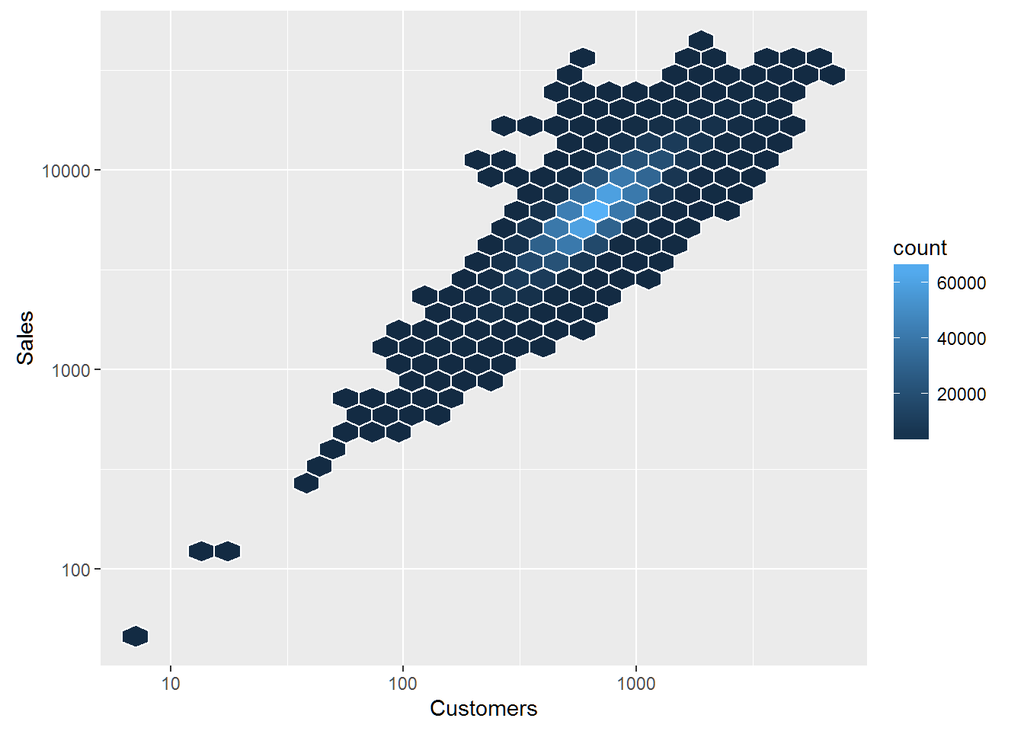

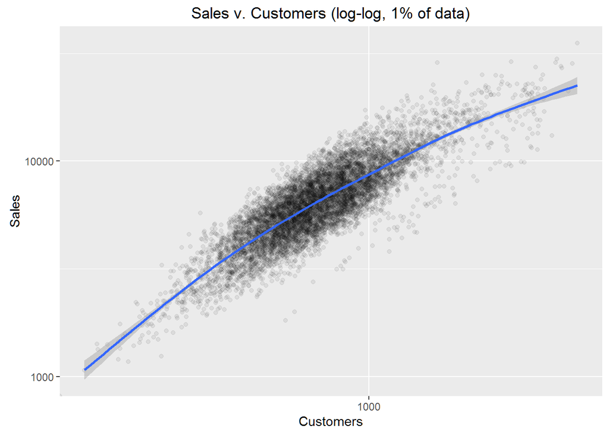

Let’s see how average sales compare on holidays and non-holidays when the store was still opened.

```r
tapply(clean$Sales, clean$SchoolHoliday, summary)
```

```
## $`0`
##    Min. 1st Qu.  Median    Mean 3rd Qu.    Max.
##       0    4826    6326    6897    8293   41550
##
## $`1`
##    Min. 1st Qu.  Median    Mean 3rd Qu.    Max.
##       0    5004    6562    7200    8647   38370
```

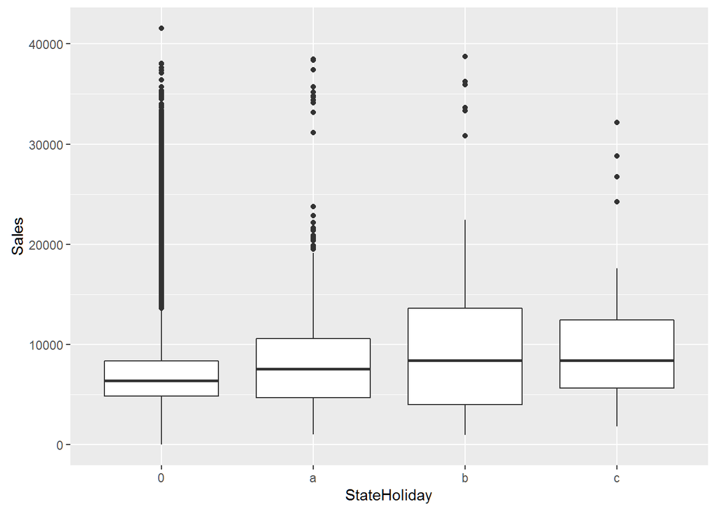

Store sales appear to increase when stores are open during the holidays.

How do sales vary with date and month?

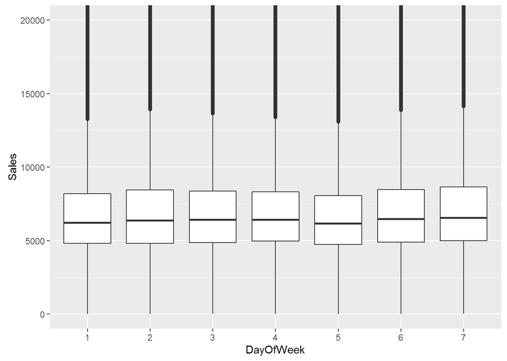

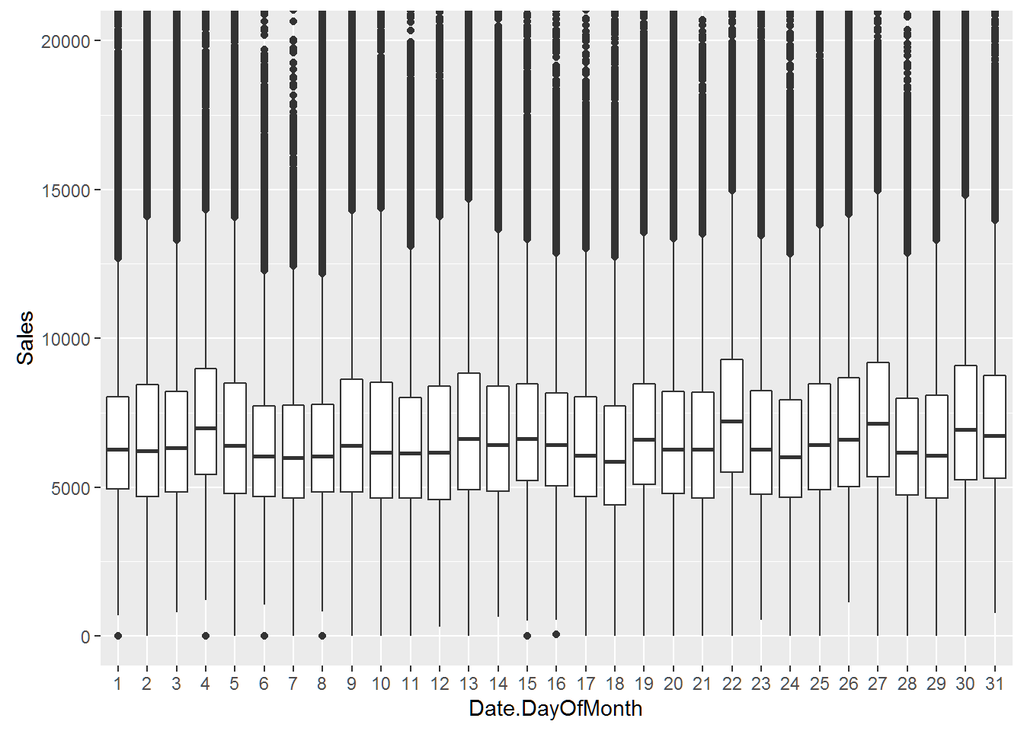

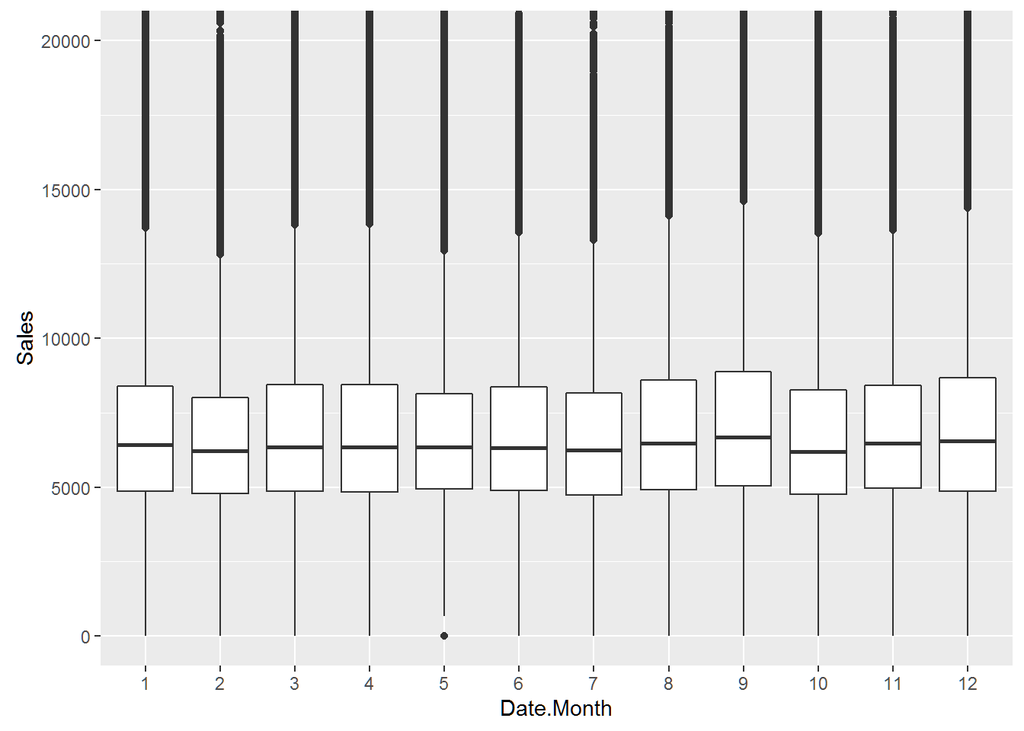

How does sales vary with promotions?

```r
# Promo
tapply(clean$Sales, clean$Promo, summary)
```

```
## $`0`
##    Min. 1st Qu.  Median    Mean 3rd Qu.    Max.
##       0    4242    5459    5929    7004   41550
##
## $`1`
##    Min. 1st Qu.  Median    Mean 3rd Qu.    Max.
##       0    6069    7649    8228    9686   38720
```

```r
# Promo2
tapply(clean$Sales, clean$Promo2, summary)
```

```
## $`0`
##    Min. 1st Qu.  Median    Mean 3rd Qu.    Max.
##       0    5090    6685    7351    8821   38720
##
## $`1`
##    Min. 1st Qu.  Median    Mean 3rd Qu.    Max.
##       0    4667    6075    6558    7912   41550
```

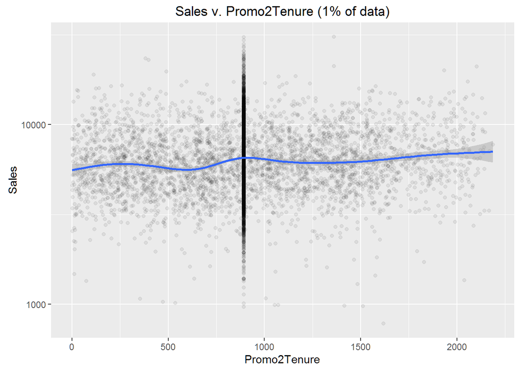

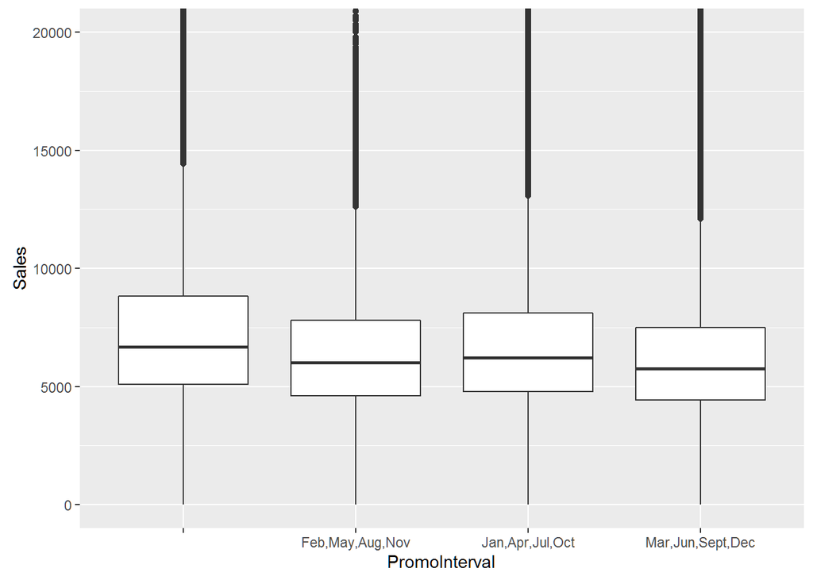

How does sales vary with store type and assortment?

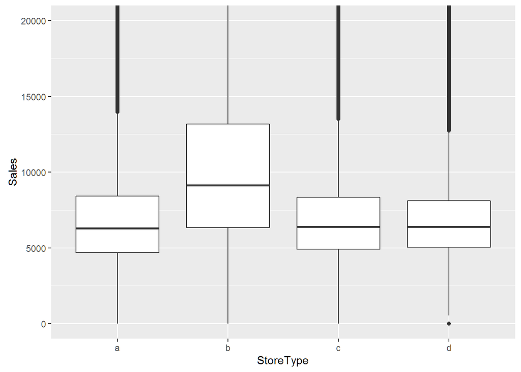

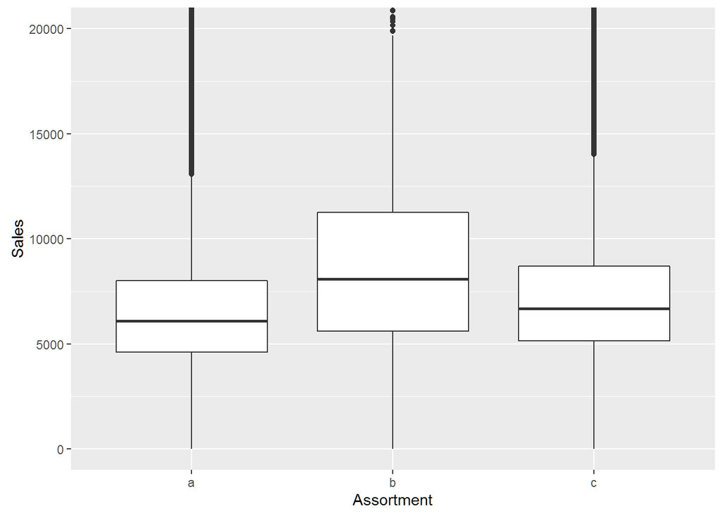

Store type-b is rare, but has the highest median sales. The other store types are comparable in sales. Likewise, stores with “extra” assortment are rare but have higher sales. “Extendend” stores are second highest in sales followed by “basic”.

Finally, lets look at the effects of competition.

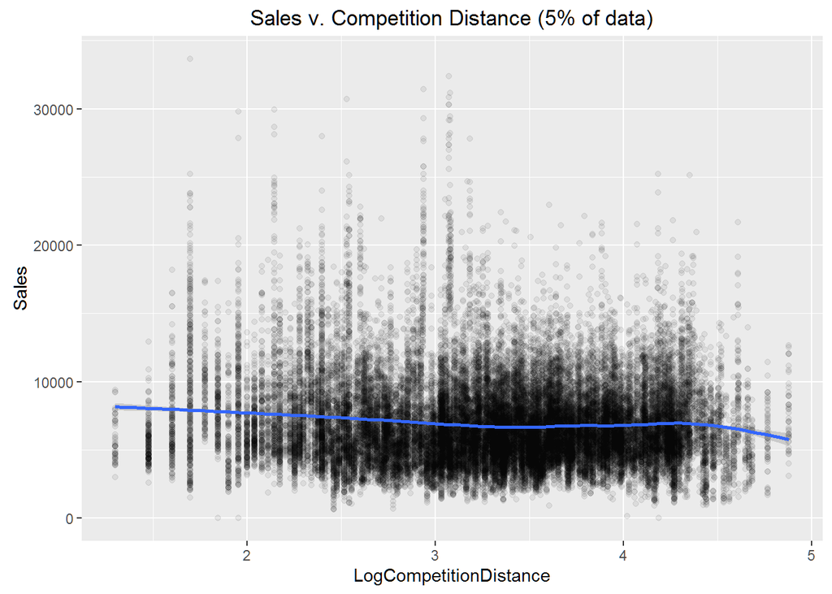

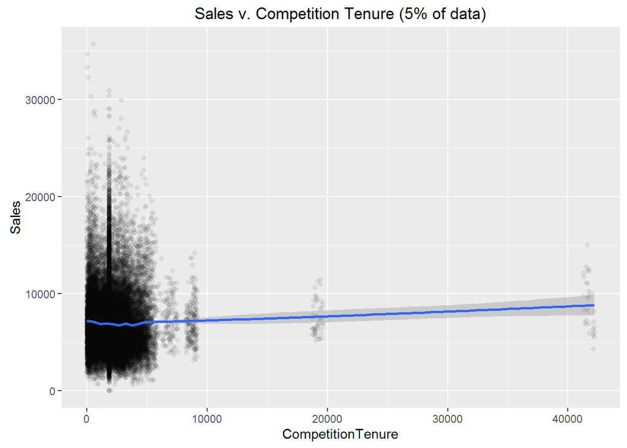

[output not shown]

Competition Distance doesn’t appear to be a large factor, and neither does Competition Tenure.